# LDA_Logistic Regression

#Prediction

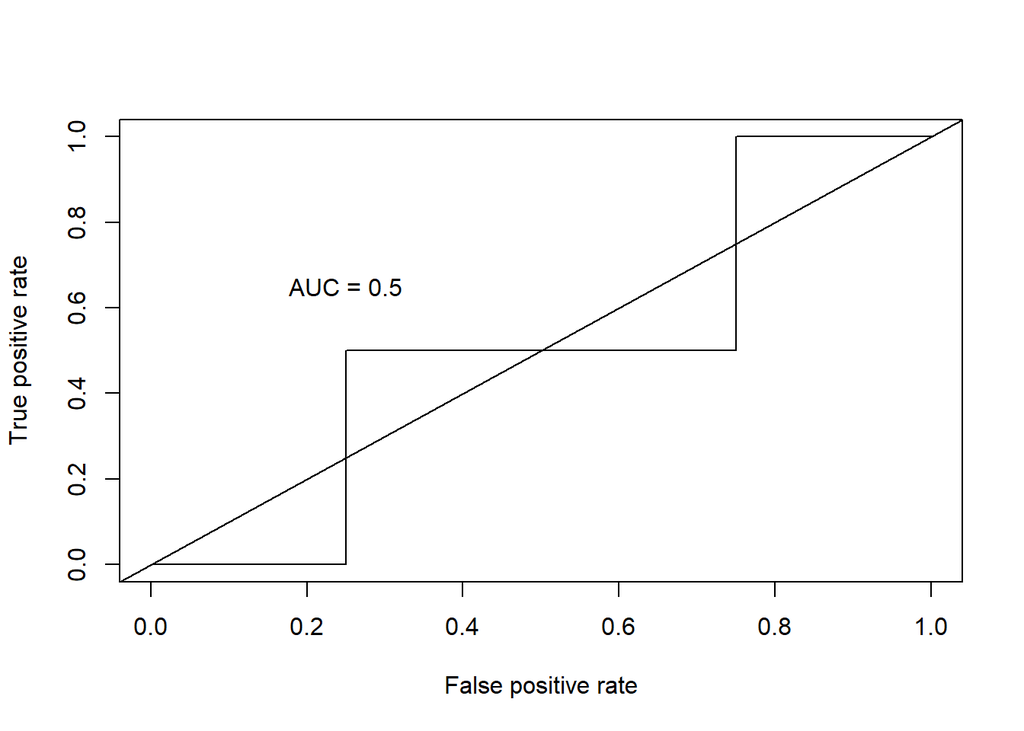

```r
wdbc_raw.lda.predict.posteriors <- as.data.frame(wdbc_raw.lda.predict_test$posterior)

pred <- prediction(wdbc_raw.lda.predict.posteriors[,2], test_raw.df$TroubleInSleep)
roc.perf = performance(pred, measure = "tpr", x.measure = "fpr")
auc.train <- performance(pred, measure = "auc")
auc.train <- auc.train@y.values
plot(roc.perf)
abline(a=0, b= 1)
text(x = .25, y = .65 ,paste("AUC = ", round(auc.train[[1]],3), sep = ""))
```

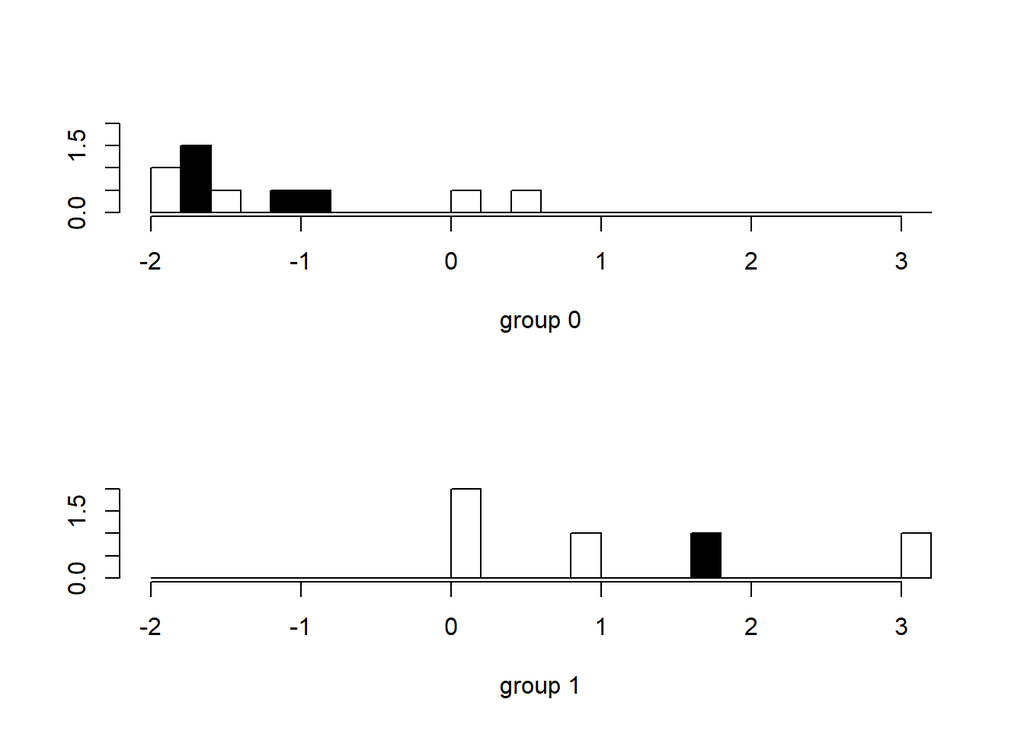

```r
plot(wdbc_raw.lda, col = as.integer(train_raw.df$TroubleInSleep))
```

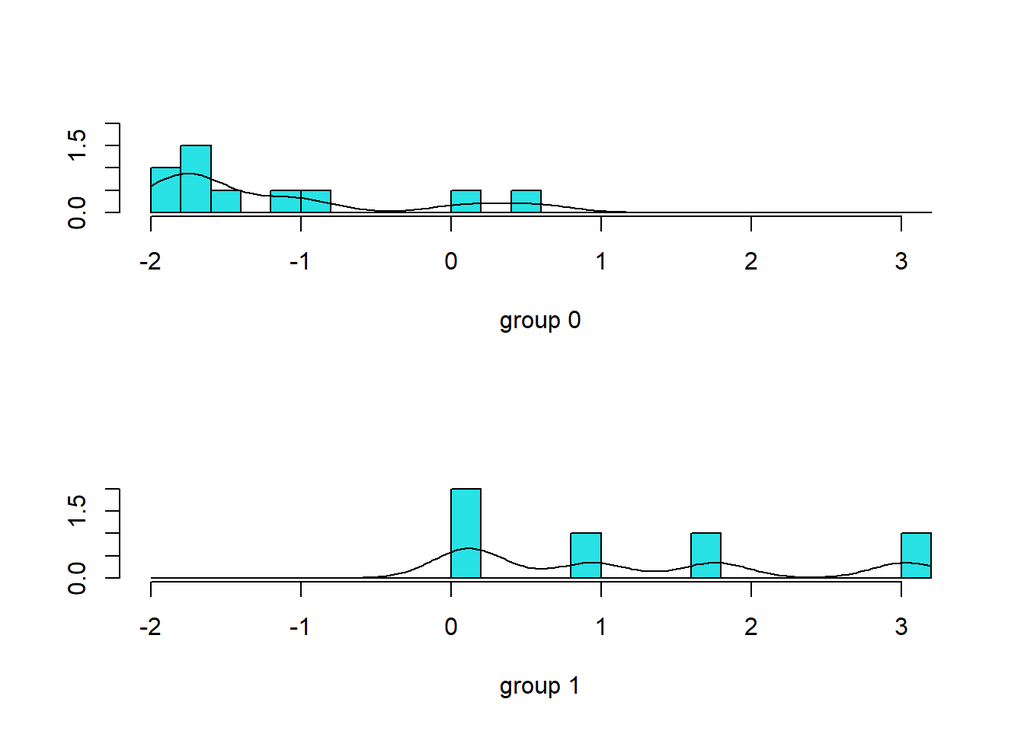

```r
plot(wdbc_raw.lda, dimen = 1, type = "b")
```

These probabilities express the model’s assurance in assigning each observation to its respective class, with higher probabilities indicating a stronger confidence in the classification. In this scenario, the ROC curve is graphed, and the AUC value is computed and depicted on the plot. An AUC value of 1 signifies flawless classification, whereas an AUC of 0.5 implies random classification. This graphical representation offers valuable insights into LD1’s efficacy in differentiating between individuals experiencing trouble falling asleep and those who are not, based on their social media usage patterns.

#Residual Analysis

```r
m <- manova(cbind(wdbc$Instagram,wdbc$LinkedIn,wdbc$Snapchat,wdbc$Twitter)~wdbc$Trouble_sleep,data=wdbc)
summary(m,test="Wilks")
```

```
##                    Df  Wilks approx F num Df den Df  Pr(>F)
## wdbc$Trouble_sleep  1 0.6295   2.3543      4     16 0.09774 .
## Residuals          19
## ---
## Signif. codes:  0 '***' 0.001 '**' 0.01 '*' 0.05 '.' 0.1 ' ' 1
```

```r
summary(m,test="Pillai")
```

```
##                    Df Pillai approx F num Df den Df  Pr(>F)
## wdbc$Trouble_sleep  1 0.3705   2.3543      4     16 0.09774 .
## Residuals          19
## ---
## Signif. codes:  0 '***' 0.001 '**' 0.01 '*' 0.05 '.' 0.1 ' ' 1
```

```r
summary.aov(m)
```

```
##  Response 1 :
##                    Df  Sum Sq Mean Sq F value Pr(>F)
## wdbc$Trouble_sleep  1   8.641  8.6405   0.936 0.3455
## Residuals          19 175.394  9.2313
##
##  Response 2 :
##                    Df  Sum Sq Mean Sq F value Pr(>F)
## wdbc$Trouble_sleep  1  10.055  10.055  0.6925 0.4156
## Residuals          19 275.867  14.519
##
##  Response 3 :
##                    Df Sum Sq Mean Sq F value Pr(>F)
## wdbc$Trouble_sleep  1  23.16  23.162   0.923 0.3488
## Residuals          19 476.80  25.095
##
##  Response 4 :
##                    Df Sum Sq Mean Sq F value   Pr(>F)
## wdbc$Trouble_sleep  1 113.75 113.752  8.2302 0.009828 **
## Residuals          19 262.60  13.821
## ---
## Signif. codes:  0 '***' 0.001 '**' 0.01 '*' 0.05 '.' 0.1 ' ' 1
```

The p-value of 0.09774 surpasses the frequently employed significance threshold of 0.05, suggesting that this effect lacks statistical significance. However, solely for Twitter, the p-value (0.009828) falls below 0.05, signifying a statistically significant impact of Trouble_sleep on Twitter utilization.